# NEW YORK CITY TAXI DATA ANALYSIS

#### Handle columns with "inf" or "nan" values

```python
print(trip_with_tips_and_dummy.columns.to_series()[np.isinf(trip_with_tips_and_dummy).any()])
print(trip_with_tips_and_dummy.index[np.isinf(trip_with_tips_and_dummy).any(1)])


# indexNames = trip_with_tips_and_dummy[(trip_with_tips_and_dummy.trip_distance<=0.0)].index

# # Delete these row indexes from dataFrame
# trip.drop(indexNames , inplace=True)
```

```python
trip_with_tips_and_dummy.info()
```

```
<class 'pandas.core.frame.DataFrame'>
Int64Index: 7928592 entries, 0 to 14995925
Data columns (total 58 columns):
index                              int64
passenger_count                    int64
trip_time_in_secs                  int64
trip_distance                      float64
pickup_longitude                   float64
pickup_latitude                    float64
dropoff_longitude                  float64
dropoff_latitude                   float64
fare_amount                        float64
surcharge                          float64
tip_amount                         float64
tolls_amount                       float64
total_amount                       float64
pickup_day_of_week                 int64
pickup_day_of_month                int64
pickup_hour                        int64
dropoff_day_of_week                int64
dropoff _day_of_month              int64
dropoff _hour                      int64
fare_amount_per_unit_distance      float64
fare_amount_per_second             float64
rate_code_0                        uint8
rate_code_1                        uint8
rate_code_2                        uint8
rate_code_3                        uint8
rate_code_4                        uint8
rate_code_5                        uint8
rate_code_6                        uint8
vendor_id_CMT                      uint8
vendor_id_VTS                      uint8
pickup_weekday_name_Friday         uint8
pickup_weekday_name_Monday         uint8
pickup_weekday_name_Saturday       uint8
pickup_weekday_name_Sunday         uint8
pickup_weekday_name_Thursday       uint8
pickup_weekday_name_Tuesday        uint8
pickup_weekday_name_Wednesday      uint8
```

[output cut: 8 more lines]

```
pickup_borough_brooklyn            uint8
pickup_borough_manhattan           uint8
pickup_borough_others              uint8
pickup_borough_queens              uint8
pickup_borough_staten_island       uint8
dropoff_borough_bronx              uint8
dropoff_borough_brooklyn           uint8
dropoff_borough_manhattan          uint8
dropoff_borough_others             uint8
dropoff_borough_queens             uint8
dropoff_borough_staten_island      uint8
mta_tax_0.0                        uint8
mta_tax_0.5                        uint8
dtypes: float64(12), int64(9), uint8(37)
memory usage: 1.6 GB
```

#### Remove any unwanted index column and resetting the index

```python
trip_with_tips_and_dummy = trip_with_tips_and_dummy.drop(columns=['index']).reset_index().drop(columns=['index'])
trip_with_tips_and_dummy.head()
```

### Export File As CSV

```python
trip_with_tips_and_dummy.to_csv("trip_with_tips_and_dummy.csv",index=False)
```

```python
# IMPORT IF KERNEL ACCIDENTALLY RESTARTS:
# trip_with_tips_and_dummy =pd.read_csv('trip_with_tips_and_dummy.csv')

trip_with_tips_and_dummy.info()
```

```
<class 'pandas.core.frame.DataFrame'>
RangeIndex: 7928592 entries, 0 to 7928591
Data columns (total 57 columns):
passenger_count                    int64
trip_time_in_secs                  int64
trip_distance                      float64
pickup_longitude                   float64
pickup_latitude                    float64
dropoff_longitude                  float64
dropoff_latitude                   float64
fare_amount                        float64
surcharge                          float64
tip_amount                         float64
tolls_amount                       float64
total_amount                       float64
pickup_day_of_week                 int64
pickup_day_of_month                int64
pickup_hour                        int64
dropoff_day_of_week                int64
dropoff _day_of_month              int64
dropoff _hour                      int64
fare_amount_per_unit_distance      float64
fare_amount_per_second             float64
rate_code_0                        int64
rate_code_1                        int64
rate_code_2                        int64
rate_code_3                        int64
rate_code_4                        int64
rate_code_5                        int64
rate_code_6                        int64
vendor_id_CMT                      int64
vendor_id_VTS                      int64
pickup_weekday_name_Friday         int64
pickup_weekday_name_Monday         int64
pickup_weekday_name_Saturday       int64
pickup_weekday_name_Sunday         int64
pickup_weekday_name_Thursday       int64
pickup_weekday_name_Tuesday        int64
pickup_weekday_name_Wednesday      int64
dropoff _weekday_name_Friday       int64
dropoff _weekday_name_Monday       int64
dropoff _weekday_name_Saturday     int64
dropoff _weekday_name_Sunday       int64
dropoff _weekday_name_Thursday     int64
dropoff _weekday_name_Tuesday      int64
dropoff _weekday_name_Wednesday    int64
pickup_borough_bronx               int64
pickup_borough_brooklyn            int64
pickup_borough_manhattan           int64
pickup_borough_others              int64
pickup_borough_queens              int64
pickup_borough_staten_island       int64
dropoff_borough_bronx              int64
dropoff_borough_brooklyn           int64
dropoff_borough_manhattan          int64
dropoff_borough_others             int64
dropoff_borough_queens             int64
dropoff_borough_staten_island      int64
mta_tax_0.0                        int64
mta_tax_0.5                        int64
dtypes: float64(12), int64(45)
memory usage: 3.4 GB
```

```python
new_features = ['passenger_count',
 'trip_time_in_secs',
 'trip_distance',
 'pickup_longitude',
 'pickup_latitude',
 'dropoff_longitude',
 'dropoff_latitude',
 'fare_amount',
 'tip_amount',
 'pickup_day_of_week',
 'pickup_day_of_month',
 'pickup_hour',
 'dropoff_day_of_week',
 'dropoff _day_of_month',
 'dropoff _hour',
 'pickup_borough_bronx',
 'pickup_borough_brooklyn',
 'pickup_borough_manhattan',
 'pickup_borough_others',
 'pickup_borough_queens',
 'pickup_borough_staten_island',
 'dropoff_borough_bronx',
 'dropoff_borough_brooklyn',
 'dropoff_borough_manhattan',
 'dropoff_borough_others',
 'dropoff_borough_queens',
 'dropoff_borough_staten_island',
]
```

### Check Collinearity of features

- Insight: The fact that coll. check only pointed out the following features as strongly linearly correlated means that features e.g. time-related ones like hour/day of week may not be linearly correlated with tip amount:
- trip_time_in_secs 0.660254
- trip_distance 0.737776
- fare_amount 0.776092
- tip_amount 1.000000
- tolls_amount 0.542131
- total_amount 0.846025

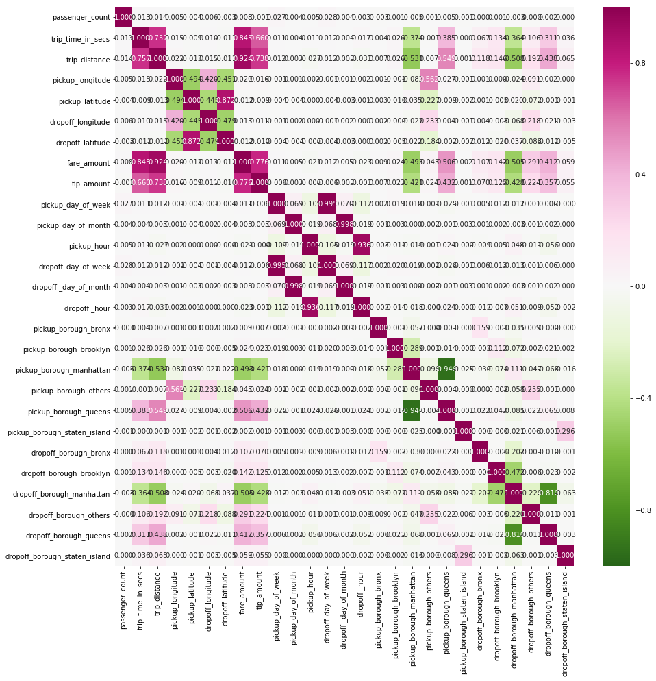

```python
corrs = trip_with_tips_and_dummy[new_features].corr()

plt.figure(figsize = (15, 15))
sns.heatmap(corrs, annot = True, vmin = -1, vmax = 1, fmt = '.3f', cmap=plt.cm.PiYG_r);
```

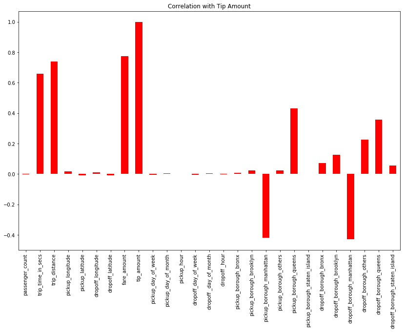

```python
plt.figure(figsize = (14, 9))
corrs = trip_with_tips_and_dummy[new_features].corr()
corrs['tip_amount'].plot.bar(color = 'r');
plt.title('Correlation with Tip Amount');
```

```python
#Using Pearson Correlation
cor = trip_with_tips_and_dummy.corr()

#Correlation with output variable
cor_target = abs(cor["tip_amount"])

#Selecting highly correlated features
relevant_features = cor_target[cor_target>0.5]
relevant_features
```

```
trip_time_in_secs    0.660254
trip_distance        0.737776
fare_amount          0.776092
tip_amount           1.000000
tolls_amount         0.542131
total_amount         0.846025
Name: tip_amount, dtype: float64
```

### Use a Feature Selection Technique to extract those features which contribute the most to the training for a particular iteration

```
- Use an Embedded Method like Lasso regularization
    - If there are < 20 features as it is computationally expensive
- Use a Filter method while doing EDA
    - is less accurate than Regularization
    - Use it for checking multi co-linearity in data as well
```

Apply a Feature Selection Technique

[output not shown]

```
Text(0.5,1,'Feature importance using Lasso Model')
```

[figure not shown]

```python
# LASSO REGULARIZATION
trip_with_tips_and_dummy_no_total_amt = trip_with_tips_and_dummy.drop(columns=['total_amount','fare_amount'])
X = trip_with_tips_and_dummy_no_total_amt.drop("tip_amount",1)   #Feature Matrix
y = trip_with_tips_and_dummy_no_total_amt["tip_amount"]          #Target Variable


reg = LassoCV()
reg.fit(X, y)
print("Best alpha using built-in LassoCV: %f" % reg.alpha_)
print("Best score using built-in LassoCV: %f" %reg.score(X,y))
coef = pd.Series(reg.coef_, index = X.columns)

print("Lasso picked " + str(sum(coef != 0)) + " variables and eliminated the other " +  str(sum(coef == 0)) + " variables")


imp_coef = coef.sort_values()
# import matplotlib
matplotlib.rcParams['figure.figsize'] = (8.0, 10.0)
imp_coef.plot(kind = "barh")
plt.title("Feature importance using Lasso Model")
```

### Running of Random Forest Regressor Model with New Features

```python
new_features
```

```
['passenger_count',
 'trip_time_in_secs',
 'trip_distance',
 'pickup_longitude',
 'pickup_latitude',
 'dropoff_longitude',
 'dropoff_latitude',
 'fare_amount',
 'tip_amount',
 'pickup_day_of_week',
 'pickup_day_of_month',
 'pickup_hour',
 'dropoff_day_of_week',
 'dropoff _day_of_month',
 'dropoff _hour',
 'pickup_borough_bronx',
 'pickup_borough_brooklyn',
 'pickup_borough_manhattan',
 'pickup_borough_others',
 'pickup_borough_queens',
 'pickup_borough_staten_island',
 'dropoff_borough_bronx',
 'dropoff_borough_brooklyn',
 'dropoff_borough_manhattan',
 'dropoff_borough_others',
 'dropoff_borough_queens',
 'dropoff_borough_staten_island']
```

##### len(new_features)

```python
#Data Splitting into Train and Validation sets
X=trip_with_tips_and_dummy[new_features].drop(columns=['fare_amount','tip_amount'],axis=1)
y=trip_with_tips_and_dummy['tip_amount']
X_train, X_test, y_train, y_test = train_test_split(X,y, test_size=0.3,random_state=5)
#test_size is the proportion of data that is to be kept aside for validation
```

```python
#Build a Model based on average results
avg_fare=round(np.mean(y_train),2) #11.31
baseline_pred=np.repeat(avg_fare,y_test.shape[0])
baseline_rmse=np.sqrt(mean_squared_error(baseline_pred, y_test))
print("Baseline RMSE of Test data :",baseline_rmse)
```

```
Baseline RMSE of Test data : 2.2723737096576477
```

```
Test RMSE for Random Forest Regressor is  1.4347916752178826
Train RMSE for Random Forest Regressor is  1.139414705437452
Variance for Random Forest Regressor is  0.2953769697804307
```

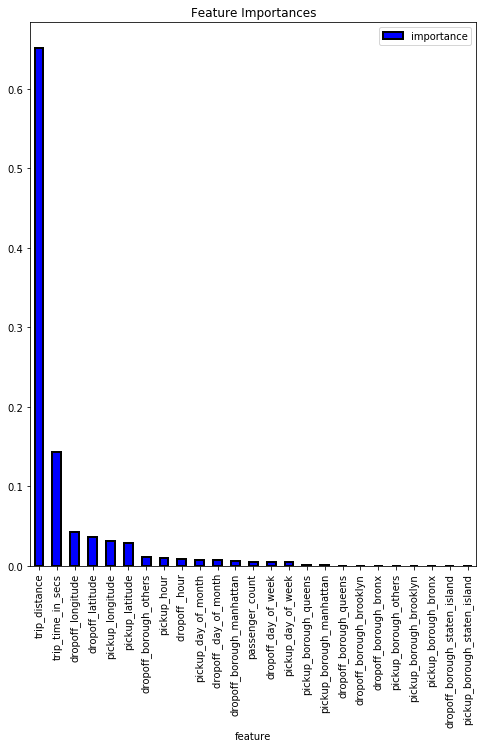

```python
#Train RF Model with different parameters
rf = RandomForestRegressor(random_state = 5,n_estimators = 20, max_depth = 20,
                                           n_jobs = -1)
rf.fit(X_train,y_train)

# Get Predictions
rf_pred= rf.predict(X_test)

# Calculate Root Mean Squared Error
rf_rmse=np.sqrt(mean_squared_error(rf_pred, y_test))  # Test/Validation RMSE
rf_train_rmse = np.sqrt(mean_squared_error(rf.predict(X_train), y_train)) # Training RMSE
rf_variance=abs(rf_train_rmse - rf_rmse)


print("Test RMSE for Random Forest Regressor is ",rf_rmse)
print("Train RMSE for Random Forest Regressor is ",rf_train_rmse)
print("Variance for Random Forest Regressor is ",rf_variance)


# Extract feature importances
feature_importances = pd.DataFrame({'feature': X_train.columns.tolist(),
                                    'importance': rf.feature_importances_}).sort_values('importance', ascending = False).set_index('feature')

feature_importances.plot.bar(color = 'b', edgecolor = 'k', linewidth = 2);
plt.title('Feature Importances');
```

#### Conclusion on Random Forest model with New Features :

The test RMSE for Random Forest model was 1.434 and train RMSE 1.139 New Features provide much further improvement over the simpler set of features. Variance has been lowered further to 0.295 Model no longer seems to overfit the training data set

## c. If you were a taxi driver, how would you maximize your earnings in a day?

#### Ways to maximize earnings

- Step 1: Define General Idea:
  - a) Try to find the day of the week, hours of the day and location (Borough) which provides
    - the highest average fare rate (Fare per unit distance / Fare per second)
    - the highest demand (Count of trips) or at least suff high demand to ensure there won't be a shortfall of passengers
  - b) To ensure consistency in results, identify those trips within the Step 1 Results that have the most consistent fares
- Step 2: Define Strategies
- a) Strategy 1: Simple Approach:
  - USE BASIC QNS 1 AND 2 TO ANSWER THIS
    - What are top 5 busiest hours of the day?
    - What are the top 10 busiest locations of the city?
- b) Strategy 2: Custom Approach:

```
- Step 1:

    - Try to find the day of the week, hours of the day and location (Borough) which provides
        - the highest average fare rate (Fare per second)
        - the highest demand (Count of trips) or at least suff high demand to ensure there won't be a shortfall of

    - **PLOT TWO HEATMAPS (Y= DAYS OF WEEK, X= HOURS OF DAY) WHERE  COLOR/VALUE = FARE AMOUNT & COUNT OF TRIPS RESPECTIVELY
    - **PLOT THESE TWO HEATMAPS FOR EACH BOROUGH
    - Identify Trips that are consistent (Fare per second and Count of Trips)


- Step 2 (Strategize based on preference): This also depends on what type of taxi driver I am / preference I may have


    - If i want to only travel within a specific borough, I should
        - Find the peak hours for that borough based on Count of Trips & average Fare Rate
            - **PLOT TWO CHARTS : #TRIPS AGAINST PICKUP HOUR + FARE RATE AGAINST PICKUP HOUR & identify the highest values
        - To ensure consistency in results, Identify trips within that borough with the
            - **Most consistent average Fare Rate (Basic Question D)
            - Most consistent Demand


    - If i don't mind travelling to another borough and then stay within that borough, I should
        - Find the borough with highest average fare rate and demand
        - To ensure consistency in results, Identify trips within that borough with the
            - **Most consistent average Fare Rate (Basic Question D)
            - Most consistent Demand


    - If i don't mind travelling across boroughs, I should
        - Find the set of boroughs with highest average fare rate and demand
        - To ensure consistency in results, Identify trips within that borough with the
            - **Most consistent average Fare Rate (Basic Question D)
            - Most consistent Demand
```

- c) Strategy 3: Optimization Approach:

```
- Define cost function for minimizing work time
- Identifying different solutions (Google Search)
```

##### Assumption: 8 hour work day.

### d. If you were a taxi driver, how would you minimize your work time while retaining the average wages earned by a typical taxi in the dataset?

#### Ways to minimize work time

- Step 1: Identify what the a typical taxi driver is
  - - May be able to skip this *
- Step 2: Identify the average wage earned by a typical taxi driver
  - Remove outliers (1.5 IQR range) and take the average wage from the remaining taxi drivers
- Step 3: Identifying Strategies

```
- Strategy 1: Figure out how to minimize work time(earning the average wage in the least amount of hours)
    - Choosing the Shortest Trip (lowest trip duration) with the highest (fare + tip) per second
    - Identify the trips with the most consistent (fare + tip) per unit distance  (Basic Question D but take the rate)
    - Select  within one borough if possible (Try to optimize for this but also cater to diff taxi driver preferences)

- Strategy 2: Defining qn as an optimization problem
    - Define cost function for minimizing work time
    - Identifying different solutions (Google Search)
```

### e. If you run a taxi company with 10 taxis, how would you maximize your earnings?